# Coursera: Practical Machine Learning Final Project

Maciej Komisarz

27th October, 2019

This document is the final project for the Coursera “Practical Machine Learning” course.  
To prepare it, I have used Markdown and Knitr packages of RStudio.

# *Project background*

Using devices such as Jawbone Up, Nike FuelBand, and Fitbit it is now possible to collect a large amount of data about personal activity relatively inexpensively. These type of devices are part of the quantified self movement – a group of enthusiasts who take measurements about themselves regularly to improve their health, to find patterns in their behavior, or because they are tech geeks. One thing that people regularly do is quantify how much of a particular activity they do, but they rarely quantify how well they do it. In this project, your goal will be to use data collected from accelerometers on the belt, forearm, arm, and dumbell of 6 participants. They were asked to perform barbell lifts correctly and incorrectly in 5 different ways.  
Dataset used in this project was made available to the wider audience as a part of research performed by group of Brazilian scientists, Ugulino, W.; Cardador, D.; Vega, K.; Velloso, E.; Milidiu, R.; Fuks, H., described in report titled “Wearable Computing: Accelerometers’ Data Classification of Body Postures and Movements”.  
Dataset consists of training data and test data (which will be used to validate the selected model).

# *Data loading and processing*

```r
library(e1071)
library(caret)
```

```r
library(rpart)
library(rpart.plot)
library(RColorBrewer)
library(rattle)
library(randomForest)
train_data <- read.csv("pml-training.csv",header=T)
test_data <- read.csv("pml-testing.csv",header=T)
dim(train_data)
```

```
## [1] 19622   160
```

```r
dim(test_data)
```

```
## [1]  20 160
```

```r
str(train_data)
```

```
## 'data.frame':    19622 obs. of  160 variables:
##  $ X                       : int  1 2 3 4 5 6 7 8 9 10 ...
##  $ user_name               : Factor w/ 6 levels "adelmo","carlitos",..: 2 2 2 2 2 2 2 2 2 2 ...
##  $ raw_timestamp_part_1    : int  1323084231 1323084231 1323084231 1323084232 1323084232 1323084232 1323084232 1323084232 1323084232 1323084232 ...
##  $ raw_timestamp_part_2    : int  788290 808298 820366 120339 196328 304277 368296 440390 484323 484434 ...
##  $ cvtd_timestamp          : Factor w/ 20 levels "02/12/2011 13:32",..: 9 9 9 9 9 9 9 9 9 9 ...
##  $ new_window              : Factor w/ 2 levels "no","yes": 1 1 1 1 1 1 1 1 1 1 ...
##  $ num_window              : int  11 11 11 12 12 12 12 12 12 12 ...
##  $ roll_belt               : num  1.41 1.41 1.42 1.48 1.48 1.45 1.42 1.42 1.43 1.45 ...
##  $ pitch_belt              : num  8.07 8.07 8.07 8.05 8.07 8.06 8.09 8.13 8.16 8.17 ...
##  $ yaw_belt                : num  -94.4 -94.4 -94.4 -94.4 -94.4 -94.4 -94.4 -94.4 -94.4 -94.4 ...
##  $ total_accel_belt        : int  3 3 3 3 3 3 3 3 3 3 ...
##  $ kurtosis_roll_belt      : Factor w/ 397 levels "","-0.016850",..: 1 1 1 1 1 1 1 1 1 1 ...
##  $ kurtosis_picth_belt     : Factor w/ 317 levels "","-0.021887",..: 1 1 1 1 1 1 1 1 1 1 ...
##  $ kurtosis_yaw_belt       : Factor w/ 2 levels "","#DIV/0!": 1 1 1 1 1 1 1 1 1 1 ...
```

[output cut: 86 more lines]

```r
str(test_data)
```

```
## 'data.frame':    20 obs. of  160 variables:
##  $ X                       : int  1 2 3 4 5 6 7 8 9 10 ...
##  $ user_name               : Factor w/ 6 levels "adelmo","carlitos",..: 6 5 5 1 4 5 5 5 2 3 ...
##  $ raw_timestamp_part_1    : int  1323095002 1322673067 1322673075 1322832789 1322489635 1322673149 1322673128 1322673076 1323084240 1322837822 ...
##  $ raw_timestamp_part_2    : int  868349 778725 342967 560311 814776 510661 766645 54671 916313 384285 ...
##  $ cvtd_timestamp          : Factor w/ 11 levels "02/12/2011 13:33",..: 5 10 10 1 6 11 11 10 3 2 ...
##  $ new_window              : Factor w/ 1 level "no": 1 1 1 1 1 1 1 1 1 1 ...
##  $ num_window              : int  74 431 439 194 235 504 485 440 323 664 ...
##  $ roll_belt               : num  123 1.02 0.87 125 1.35 -5.92 1.2 0.43 0.93 114 ...
##  $ pitch_belt              : num  27 4.87 1.82 -41.6 3.33 1.59 4.44 4.15 6.72 22.4 ...
##  $ yaw_belt                : num  -4.75 -88.9 -88.5 162 -88.6 -87.7 -87.3 -88.5 -93.7 -13.1 ...
##  $ total_accel_belt        : int  20 4 5 17 3 4 4 4 4 18 ...
##  $ kurtosis_roll_belt      : logi  NA NA NA NA NA NA ...
##  $ kurtosis_picth_belt     : logi  NA NA NA NA NA NA ...
##  $ kurtosis_yaw_belt       : logi  NA NA NA NA NA NA ...
```

[output cut: 86 more lines]

As we can see above, training data contain 19622 observations and 160 variables, whereas test data contain 20 observations and 160 variables. However, many columns have NA or blank values on almost every observation. Due to this we will remove them, as they will not produce any information. Also, the first seven columns give information about the people who did the test, and also timestamps. As these information are not relevant, we will not include them in our final model. Operation will be done on both datasets.

```r
# In order to not loose too many data, we will remove only these observations with at least 85% of NAs or blank values from test dataset.
NA_BLrm_tr <- which(colSums(is.na(train_data)
|train_data=="")>0.85*dim(train_data)[1])
train_data_red <- train_data[,-NA_BLrm_tr]
train_data_fin <- train_data_red[, -c(1:7)]
dim(train_data_fin)
```

```
## [1] 19622    53
```

```r
NA_BLrm_te <- which(colSums(is.na(test_data) |test_data=="")>0.85*dim(test_data)[1])
test_data_red <- test_data[,-NA_BLrm_te]
test_data_fin <- test_data_red[, -c(1:7)]
dim(test_data_fin)
```

```
## [1] 20 53
```

After cleaning, both the new training data and test data sets have only 53 columns.

# *Preparation of the datasets for prediction*

Having cleared the test and trainig data, we will prepare the data for prediction by splitting the training data into 75% as train data and 25% as test data. This splitting will serve also for computing the out-of-sample errors.

```r
set.seed(15324)
inTrain <- createDataPartition(train_data_fin$classe, p = 0.75, list = FALSE)
trainData <- train_data_fin[inTrain, ]
testData <- train_data_fin[-inTrain, ]
dim(trainData)
```

```
## [1] 14718    53
```

```r
dim(testData)
```

```
## [1] 4904   53
```

# *Model building*

In this point we will test 3 different models:  
1. classification tree  
2. random forest  
3. gradient boosting method  
In order to limit the effects of overfitting, and to improve the efficicency of the models, we will use the cross-validation technique.

# *Classification tree*

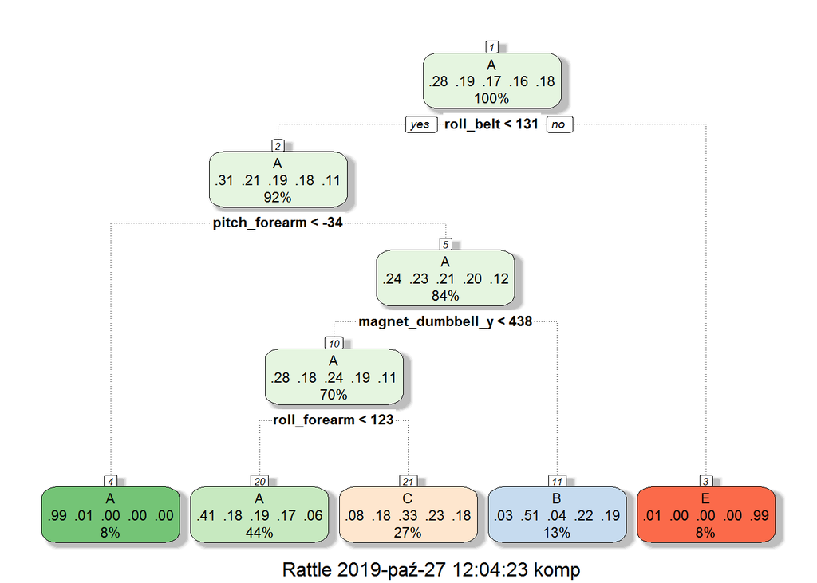

```r
trControl <- trainControl(method="cv", number=5)
CTmodel <- train(classe~., data=trainData, method="rpart", trControl = trControl)
fancyRpartPlot(CTmodel$finalModel)
```

```r
#Accuracy of the model & confusion matrix
train_pred1  <- predict(CTmodel,newdata=testData)
conf_Mat_CT <- confusionMatrix(testData$classe,train_pred1)
conf_Mat_CT$table
```

```
##           Reference
## Prediction    A    B    C    D    E
##          A 1270   30   90    0    5
##          B  395  308  246    0    0
##          C  393   25  437    0    0
##          D  353  157  294    0    0
##          E  133  118  257    0  393
```

```r
conf_Mat_CT$overall[1]
```

```
##  Accuracy
## 0.4910277
```

As we can see, accuracy of this first model is very low - only 49,1%. This means we have to find model which is fitted better.

# *Random forests*

```r
RFControl <- trainControl(method="cv", number=3, verboseIter=FALSE)
RFmodel <- train(classe~., data=trainData, method="rf", trControl=RFControl, verbose=FALSE)
print(RFmodel)
```

```
## Random Forest
##
## 14718 samples
##    52 predictor
##     5 classes: 'A', 'B', 'C', 'D', 'E'
##
## No pre-processing
## Resampling: Cross-Validated (3 fold)
## Summary of sample sizes: 9812, 9812, 9812
## Resampling results across tuning parameters:
##
##   mtry  Accuracy   Kappa
##    2    0.9886533  0.9856437
##   27    0.9892648  0.9864173
##   52    0.9805680  0.9754147
##
## Accuracy was used to select the optimal model using the largest value.
## The final value used for the model was mtry = 27.
```

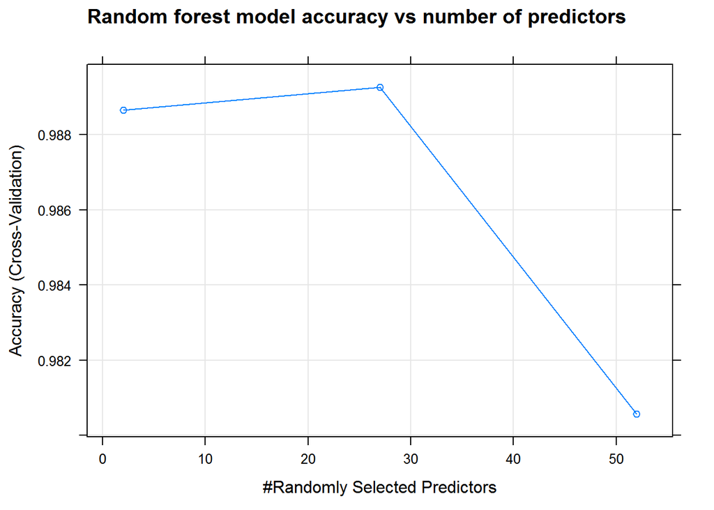

```r
plot(RFmodel,main="Random forest model accuracy vs number of predictors")
```

```r
#Accuracy of the model & confusion matrix
train_pred2 <- predict(RFmodel,newdata=testData)
conf_Mat_RF <- confusionMatrix(testData$classe,train_pred2)
conf_Mat_RF$table
```

```
##           Reference
## Prediction    A    B    C    D    E
##          A 1392    2    0    0    1
##          B    5  939    4    1    0
##          C    0    1  851    3    0
##          D    0    0    5  797    2
##          E    0    0    3    0  898
```

```r
conf_Mat_RF$overall[1]
```

```
##  Accuracy
## 0.9944943
```

# *Gradient boosting method*

```r
GBMControl <- trainControl(method = "repeatedcv", number = 5, repeats = 1)
GBMmodel <- train(classe~., data=trainData, method="gbm", trControl=GBMControl, verbose=FALSE)
print(GBMmodel)
```

```
## Stochastic Gradient Boosting
##
## 14718 samples
##    52 predictor
##     5 classes: 'A', 'B', 'C', 'D', 'E'
##
## No pre-processing
## Resampling: Cross-Validated (5 fold, repeated 1 times)
## Summary of sample sizes: 11776, 11774, 11773, 11774, 11775
## Resampling results across tuning parameters:
##
##   interaction.depth  n.trees  Accuracy   Kappa
##   1                   50      0.7492163  0.6820577
##   1                  100      0.8218496  0.7745642
##   1                  150      0.8543953  0.8157269
##   2                   50      0.8556858  0.8171644
##   2                  100      0.9044030  0.8790274
##   2                  150      0.9294064  0.9106666
##   3                   50      0.8935986  0.8653051
##   3                  100      0.9408211  0.9251165
##   3                  150      0.9615440  0.9513493
##
## Tuning parameter 'shrinkage' was held constant at a value of 0.1
##
## Tuning parameter 'n.minobsinnode' was held constant at a value of 10
## Accuracy was used to select the optimal model using the largest value.
## The final values used for the model were n.trees = 150,
##  interaction.depth = 3, shrinkage = 0.1 and n.minobsinnode = 10.
```

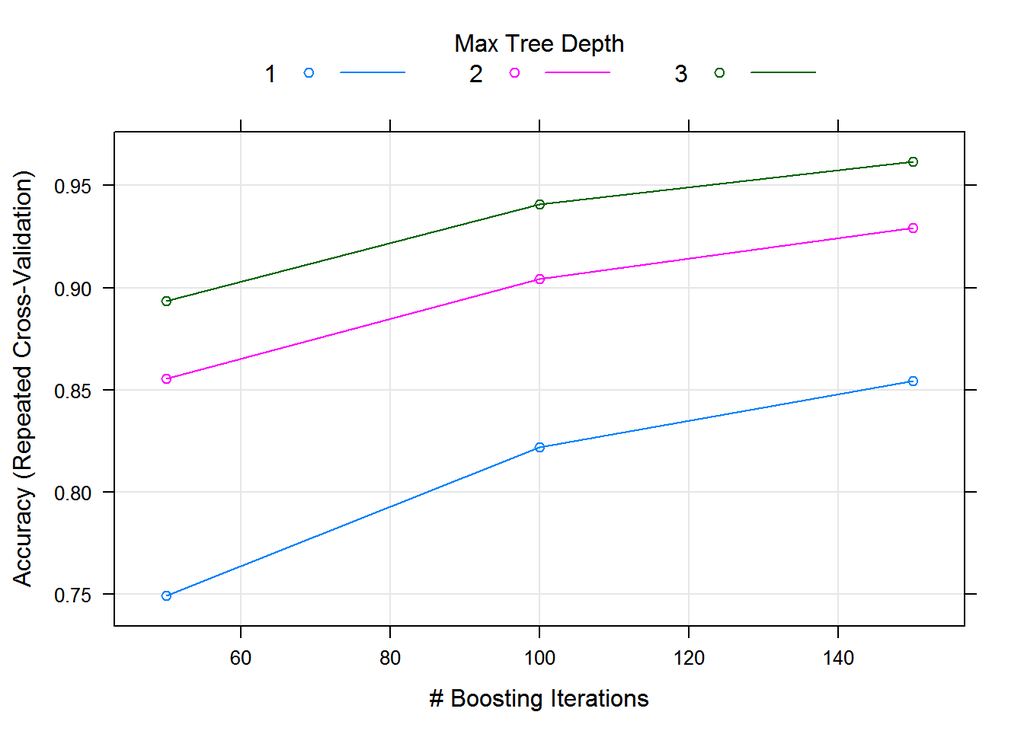

```r
plot(GBMmodel)
```

```r
#Accuracy of the model & confusion matrix
train_pred3 <- predict(GBMmodel,newdata=testData)
conf_Mat_GBM <- confusionMatrix(testData$classe,train_pred3)
conf_Mat_GBM$table
```

```
##           Reference
## Prediction    A    B    C    D    E
##          A 1373   15    3    2    2
##          B   32  888   28    1    0
##          C    0   17  835    3    0
##          D    0    4   24  771    5
##          E    3    5    6    5  882
```

```r
conf_Mat_GBM$overall[1]
```

```
##  Accuracy
## 0.9683931
```

Accuracy with gradient boosting method is again quite high, almost 97%. Best results were aquired for 150 iterations and integration depth of 3.

# *Conclusions*

```r
last_pred <- predict(RFmodel,newdata=test_data_fin)
last_pred
```

```
##  [1] B A B A A E D B A A B C B A E E A B B B
## Levels: A B C D E
```